# Tp noté - Apprentissage supervisé 2A

Cheryl Kouadio

```r
set.seed(2023)
library(data.table)
library(ggplot2)
library(dplyr)
library(tidyr)
library(rpart)
library(rpart.plot)
library(caret)
library(ranger)
library(reticulate)
```

# Partie 1 - Chargement du jeu de données, analyse exploratoire

Le jeu de données comprend des mesures effectuées 1599 vins. Ainsi, pour chaque vin, il a été mesuré 12 caractéristiques à savoir :

- L’acidité fixe (`fixed.acidity`)
- L’acidité volatile (`volatile.acidity`)
- L’acide citrique (`citric.acid`)
- Le sucre résiduel (`residual.sugar`)
- Le chlorure (`chlorides`)
- Le dioxyde de soufre libre(`free.sulfur.dioxide`)
- Le dioxyde de soufre total(`total.sulfur.dioxide`)
- La densité(`density`)
- Le pH allant de 0 à 14 (plus le pH est bas, plus le vin est acide)
- Le sulfate (`sulphates`)
- L’alcool (`alcohol`)
- La note sur la qualité du vin (`quality`).

Il s’agira à la fin de ce tp de prédire une note pour chaque vin, reflétant sa qualité.

```r
#chargement des données
wine_quality<-fread("Donnees_qualite_vins.csv")
names(wine_quality)<-make.names(names(wine_quality))
```

## 1. Analyse descriptive univariée des variables

Avant toute analyse descriptive de nos variables, il est important de vérifier que nos données ne contiennent aucune valeur manquante.

```r
colSums(is.na(wine_quality))
```

```
##        fixed.acidity     volatile.acidity          citric.acid
##                    0                    0                    0
##       residual.sugar            chlorides  free.sulfur.dioxide
##                    0                    0                    0
## total.sulfur.dioxide              density                   pH
##                    0                    0                    0
##            sulphates              alcohol              quality
##                    0                    0                    0
```

Nous constatons que nos données ne contiennent aucune valeur manquante. Cette constatation est prometteuse car elle signifie que nos données sont **complètes**, ce qui est essentiel pour la construction d’un modèle de régression fiable.

### 1.1 Qualité du vin (quality)

La variable `quality` constitue ici notre variable d’intérêt pour la régression à effectuer. Cette variable est discrète et prend des valeurs entières entre 3(pour un vin de mauvaise qualité) et 8 (pour un vin de meilleur qualité).

En moyenne, les vins ont une note de $5,636$. De fait, nous constatons que qu’au moins 50% des vins ont une note supérieur à la moyenne.

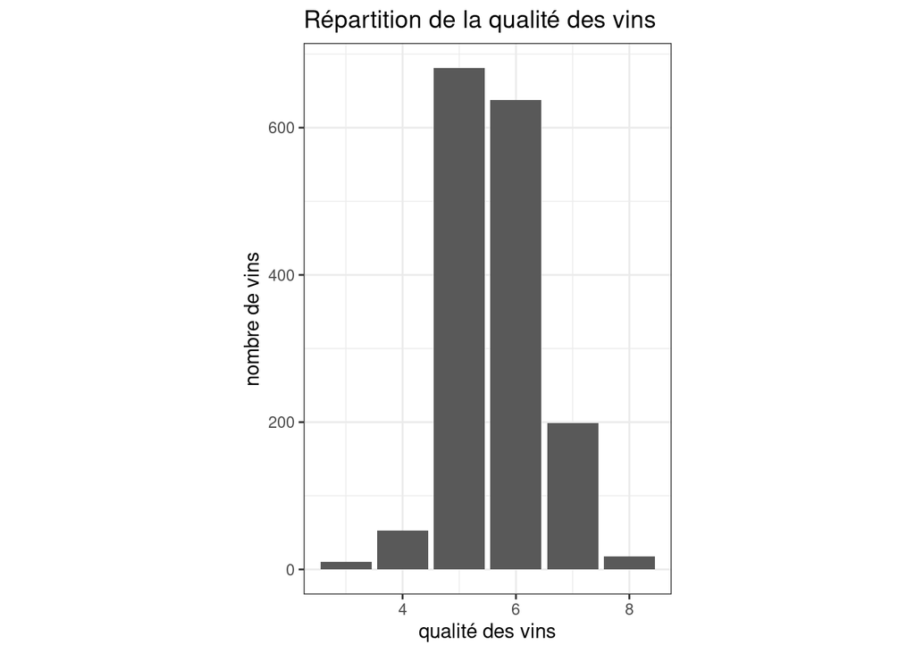

```r
ggplot(wine_quality,aes(x=quality))+
  geom_bar()+
  theme_bw()+
  labs(title ="Répartition de la qualité des vins",x="qualité des vins", y="nombre de vins")+theme(aspect.ratio = 1.5)
```

```r
round(prop.table(table(wine_quality$quality)),2)
```

```
##
##    3    4    5    6    7    8
## 0.01 0.03 0.43 0.40 0.12 0.01
```

Par ailleurs,la majorité de nos vins obtient une note de 5 (43% des vins) ou 6 (40% des vins).

Nous pourrons considérer cette variable comme étant catégorielle étant donnée le faible nombre de valeurs qu’elle prend. Le problème posé ici peut être donc vu comme un problème de classification tout comme un problème de régression.

### 1.2 Acidité fixe (fixed.acidity)

L’acidité fixe dans un vin correspond à la quantité d’acides fixes présents naturellement dans le vin.

Les vins de notre ensemble de données présentent une acidité fixe moyenne de $8,32$. Cependant, il est intéressant de noter que la médiane de l’acidité fixe se situe à 7,90, ce qui indique qu’un peu plus de la moitié des vins sont plus acides que d’autres.

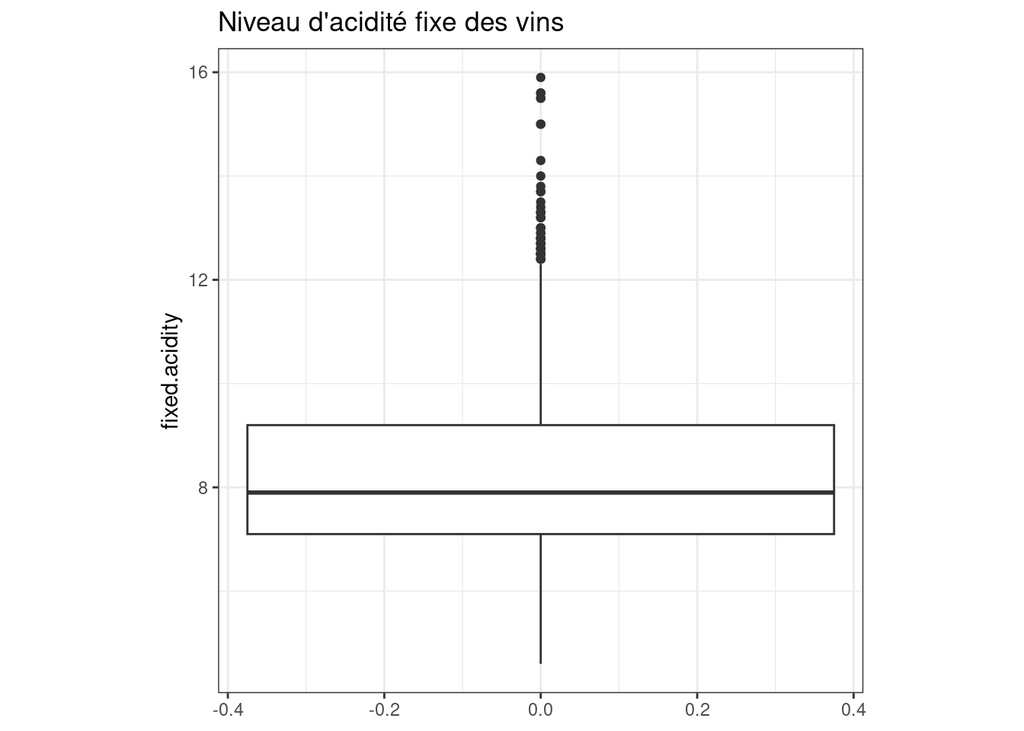

```r
ggplot(wine_quality,aes(y=fixed.acidity))+
  geom_boxplot()+
  theme_bw()+
  labs(title ="Niveau d'acidité fixe des vins")+
  theme(aspect.ratio = 1)
```

De plus, l’acidité fixe des vins est compris entre $4,60$ à $15,90$ avec une dispersion de $\sigma^2=3.03$. Cette variation signifie que certains vins affichent une acidité plus élevée que d’autres, ce qui contribue à une grande diversité au sein de l’échantillon.

### 1.3 Acidité Volatile (volatile.acidity)

L’acidité volatile dans un vin correspond à la quantité d’acides volatils qu’il contient, c’est à dire des acides qui sont capables de s’évaporer après la vinification.

Dans notre jeu de données, nous constatons que l’acidité volatile s’étend de 0.1200 à 1.5800, avec une moyenne d’environ 0.5278. Ainsi, certains vins présentent une acidité volatile plus élevée que d’autres.

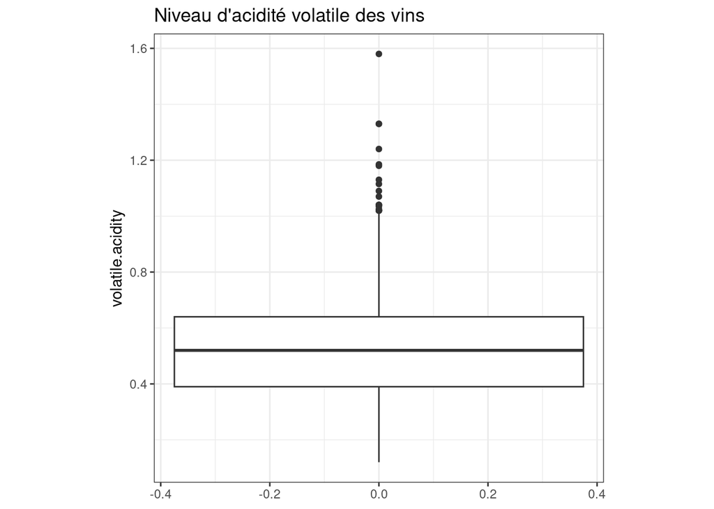

```r
ggplot(wine_quality,aes(y=volatile.acidity))+
  geom_boxplot()+
  theme_bw()+
  labs(title ="Niveau d'acidité volatile des vins")+
  theme(aspect.ratio = 1)
```

### 1.4 Acide Citrique (citric.acid)

La teneur en acide citrique varie de 0 à 1, avec une moyenne d’environ 0.271. 50% des vins ont un niveau d’acide citrique inférieur à la moyenne.

```r
summary(wine_quality$citric.acid)
```

```
##    Min. 1st Qu.  Median    Mean 3rd Qu.    Max.
##   0.000   0.090   0.260   0.271   0.420   1.000
```

On observe également une certaine variabilité des teneurs en acide citrique dans cet échantillon. En effet, le 1er quart des observations a une acidité inférieure à 0.09 , tandis que le dernier quart a une acidité supérieure à 0.42. De fait, certains vins sont quasi dépourvus en acide citrique tandis que d’autres sont riches en cet acide.

### 1.5 Sucre Résiduel (residual.sugar)

Le sucre résiduel fait référence à la quantité de sucre restant dans un vin après la fermentation alcoolique.

```r
summary(wine_quality$residual.sugar)
```

```
##    Min. 1st Qu.  Median    Mean 3rd Qu.    Max.
##   0.900   1.900   2.200   2.539   2.600  15.500
```

On constate également une certaine variabilité des teneurs en sucre résiduel. Le premier quartile à 1.9 montre que 25% des vins ont un sucre résiduel inférieur à cette valeur. A l’opposé, 25% dépassent 2.6 d’après le troisième quartile.

Bien que la majorité se concentre autour de la moyenne aux alentours de 2-3 , certains vins sont très faiblement dotés en sucre résiduel tandis que d’autres en contiennent des doses importantes, pouvant aller jusqu’à 15.

### 1.6 Chlores (chlorides)

Le chlore (chloride) est un élément chimique présent naturellement dans le vin. Il s’agit de l’ion chlorure Cl-.

```r
summary(wine_quality$chlorides)
```

```
##    Min. 1st Qu.  Median    Mean 3rd Qu.    Max.
## 0.01200 0.07000 0.07900 0.08747 0.09000 0.61100
```

Dans notre jeu de données, nous constatons que 25% des vins ont une teneur inférieure à 0.07 L. De plus, la moitié des vins ont moins de 0.079 de teneur en chlore, soit moins de la moyenne qui est de 0.08.

La majorité des vins ont une concentration en chlorure située entre 0.07 et 0.09 g/L, avec quelques valeurs extrêmes plus faibles et plus élevées.

### 1.7 Dioxyde de Soufre Libre (free.sulfur.dioxide)

Le dioxyde de soufre libre (SO2 libre) est une forme de dioxyde de soufre (SO2) que l’on trouve naturellement ou que l’on ajoute au vin. C’est la forme active du dioxyde de soufre dans le vin, essentielle pour sa conservation.

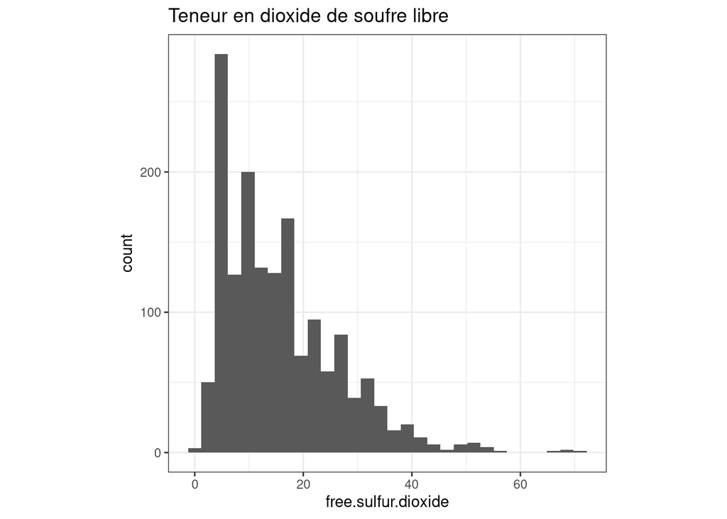

```r
ggplot(wine_quality,aes(x=free.sulfur.dioxide))+
  geom_histogram(bins=30)+
  theme_bw()+
  labs(title ="Teneur en dioxide de soufre libre")+
  theme(aspect.ratio = 1)
```

On constate donc une grande variabilité des niveaux de dioxyde de soufre libre, avec des vins quasi dépourvus tandis que d’autres en sont très riches. L’étendue entre les quartiles et les valeurs extrêmes met en évidence cette diversité des teneurs en dioxyde de soufre libre au sein de l’échantillon étudié.

### 1.8 Dioxyde de Soufre Total (total.sulfur.dioxide)

Le dioxyde de soufre total (SO2 total) est l’autre forme de dioxyde de soufre dans le vin. Il est un composé chimique utilisé couramment comme additif dans le processus de vinification.

```r
summary(wine_quality$total.sulfur.dioxide)
```

```
##    Min. 1st Qu.  Median    Mean 3rd Qu.    Max.
##    6.00   22.00   38.00   46.47   62.00  289.00
```

Ces statistiques mettent en évidence la diversité des sulfitages totaux pour les vins de cet échantillon. L’interprétation de ces teneurs nécessite de considérer le type de vin, afin de juger si les apports en SO2 sont adaptés ou excessifs.

### 1.9 Densité (density)

La densité du vin est généralement mesurée en gramme par centimètre cube (g/cm³).

```r
summary(wine_quality$density)
```

```
##    Min. 1st Qu.  Median    Mean 3rd Qu.    Max.
##  0.9901  0.9956  0.9968  0.9967  0.9978  1.0037
```

La valeur minimale de 0.9901 indique la présence de vins avec une densité très faible. Le premier quartile à 0.9956 montre que 25% des vins ont une densité inférieure à ce seuil. La médiane à 0.9968 signifie que la moitié des observations sont en dessous de cette valeur. Le troisième quartile à 0.9978 révèle que 25% des vins ont une densité qui dépasse 0.9978. Enfin, la valeur maximale atteint 1.0037, démontrant l’existence de vins avec des densités très élevées.

On constate donc une certaine variabilité des densités, avec un écart important entre les quartiles et les valeurs extrêmes. Certains vins ont une densité assez faible alors que d’autres atteignent le seuil de 1,0037 indiquant une densité très importante.

### 1.10 pH

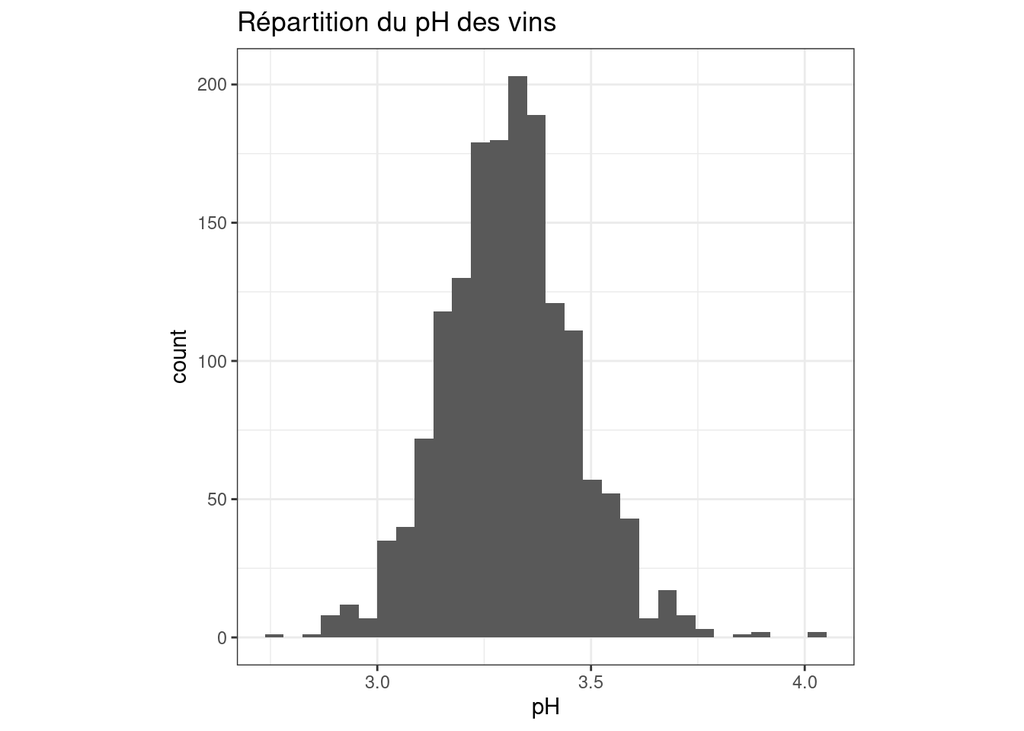

```r
ggplot(wine_quality,aes(x=pH))+
  geom_histogram(bins = 30)+
  theme_bw()+
  labs(title ="Répartition du pH des vins",x="pH")+
  theme(aspect.ratio = 1)
```

On remarque d’emblée que les vins de cet échantillon présentent des pH relativement homogènes et resserrés. En effet, 50% des observations (l’intervalle entre le 1er et le 3e quartile) sont comprises entre 3.21 et 3.4. La moyenne de 3.311 et la médiane à 3.31 indiquent une distribution centrée. Les valeurs extrêmes sont peu éloignées avec un minimum à 2.74 et un maximum à 4.01.

Cette faible dispersion des pH autour de la moyenne suggère une certaine cohérence des vins analysés en termes d’acidité. Quelques vins se démarquent avec un pH plus acide (minimum) ou plus basique (maximum), mais l’essentiel des échantillons affiche un pH entre 3.2 et 3.4.

### 1.11 Sulfates (sulphates)

Les sulfates, ou plus spécifiquement le dioxyde de soufre (SO2), sont couramment utilisés dans l’industrie vinicole comme additif.

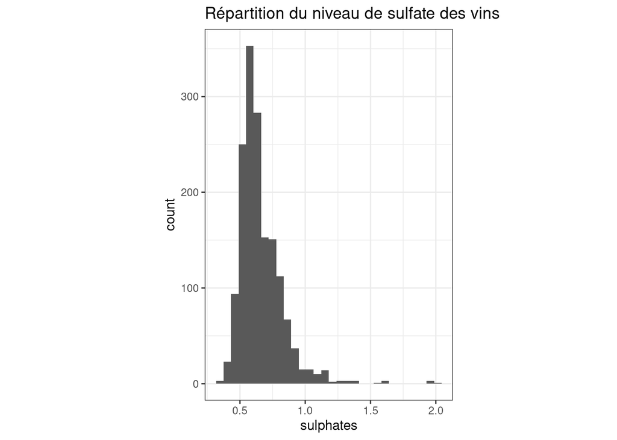

```r
ggplot(wine_quality,aes(x=sulphates))+
  geom_histogram(bins = 30)+
  theme_bw()+
  labs(title ="Répartition du niveau de sulfate des vins")+
  theme(aspect.ratio = 1.5)
```

On observe pour les sulfates une distribution plus dispersée que pour le pH précédemment étudié. Bien que l’intervalle interquartile soit resserré entre 0.55 et 0.73, les valeurs extrêmes s’étalent de 0.33 à 2.00.

Cette amplitude plus large induit une moyenne de 0.6581 plus éloignée de la médiane à 0.62. La dispersion plus importante se visualise également avec l’étendue du 1er au 3e quartile.

Cette variabilité plus marquée des sulfates signifie que les vins analysés présentent des concentrations diverses en cet élément. Si la majorité affiche une teneur groupée entre 0.55 et 0.73, certains vins s’en distinguent avec des sulfates très faibles ou au contraire particulièrement élevés. Ils peuvent jouer un rôle dans la stabilité du vin.

### 1.12 Alcool (alcohol)

La teneur en alcool est l’une des caractéristiques les plus importantes du vin.

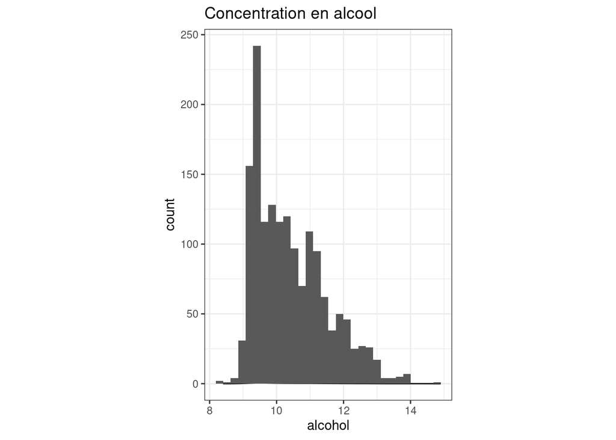

```r
ggplot(wine_quality,aes(x=alcohol))+
  geom_density() +
    geom_histogram(bins = 30)+
  theme_bw()+
  labs(title ="Concentration en alcool")+
    theme(aspect.ratio = 1.5)
```

Cette amplitude traduit une diversité des titres alcoométriques parmi les vins analysés. La moyenne de 10.42, légèrement supérieure à la médiane de 10.2, confirme une asymétrie positive de la distribution.

Certains vins se démarquent donc avec des degrés d’alcool marqués, au-delà de 14°, quand d’autres restent sur une teneur plus modérée.

## 2. Analyse visuelle bivariée entre les variables

### 2.1 Les relations entre les variables explicatives :

L’analyse graphique des relations entre les variables explicatives montre que la majorité des couples de variables ne présentent pas de relation linéaire visible. Cependant, quelques exceptions apparaissent avec des corrélations linéaires visuelles notables :

-Une relation positive entre fixed.acidity (acidité fixe) et citric.acid (acidité citrique) : quand l’acidité fixe augmente, l’acidité citrique a tendance à augmenter aussi.

-Une corrélation positive également entre fixed.acidity et density (densité) : plus l’acidité fixe est élevée, plus la densité du vin a tendance à être importante.

-A l’inverse, une relation linéaire négative semble se dégager entre fixed.acidity et le pH des vins : le pH diminue lorsque l’acidité fixe croît.

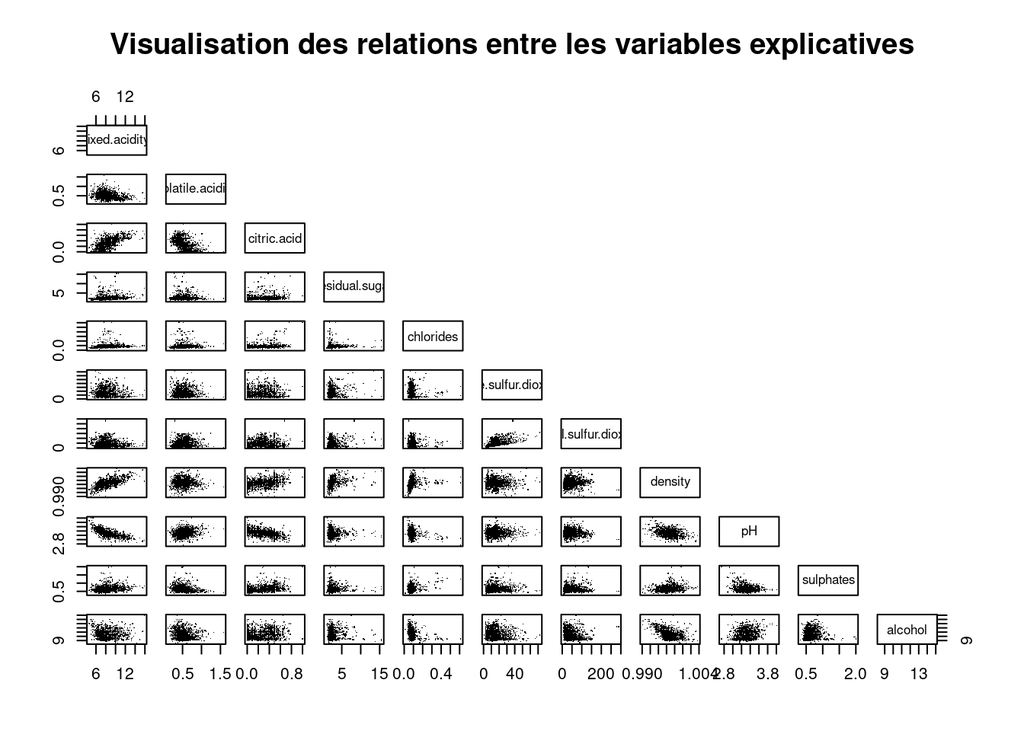

```r
pairs(wine_quality[,-12], pch = ".",upper.panel = NULL,
      main="Visualisation des relations entre les variables explicatives")
```

Cette analyse graphique préliminaire met en évidence quelques relations linéaires visuelles intéressantes entre certains couples de variables explicatives. Des analyses complémentaires permettront de confirmer et quantifier précisément ces corrélations.

### 2.2 Les variables qui influent sur la qualité du vin

Puisque la variable à prédire (la note du vin) est discrète, il est pertinent de la considérer comme une variable catégorielle pour l’analyse graphique. L’objectif étant d’évaluer visuellement l’influence des variables explicatives sur cette note qualitative, la représentation adaptée n’est pas un nuage de points.

En effet, un nuage de points convient pour analyser des relations continues entre variables quantitatives continues. La visualisation la plus appropriée consiste donc à représenter la distribution de chaque variable explicative en fonction des classes de la variable à prédire, à savoir les différentes notes de qualité des vins.

On utilisera pour cela des boîtes à moustaches (boxplots) pour chaque variable explicative, en découpant les données par classes de note de qualité.

Cette représentation permettra de visualiser si les caractéristiques des vins (variables explicatives) ont tendance à varier selon la note qualitative obtenue. Des différences de distribution mettront en évidence des variables potentiellement prédictives du niveau de qualité du vin.

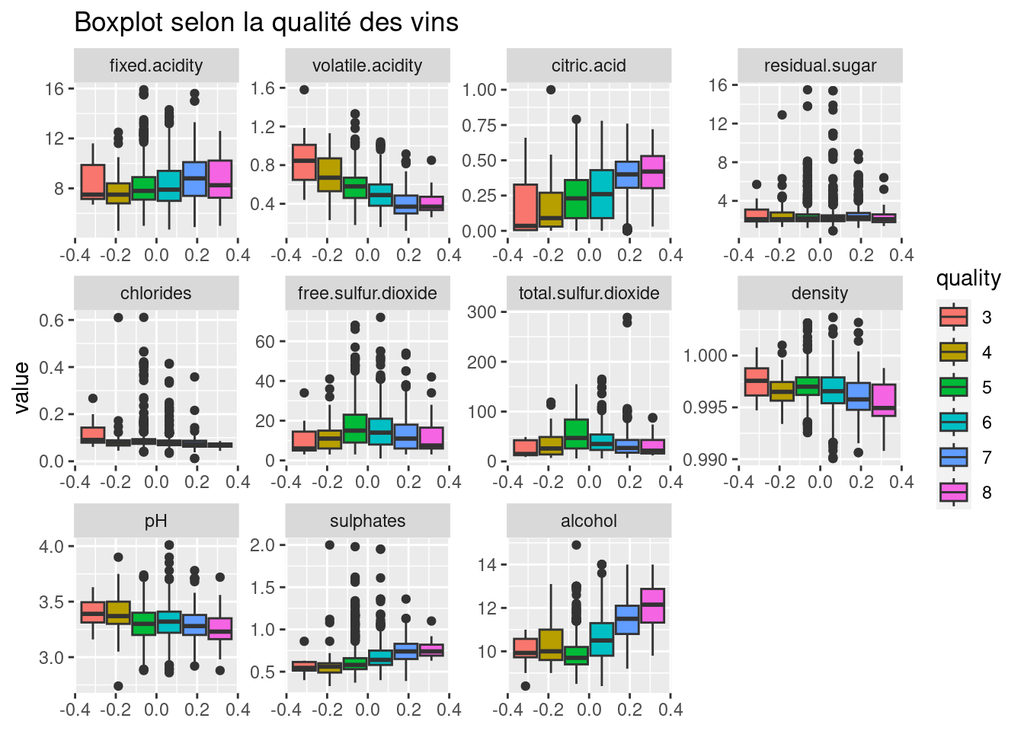

```r
### essayer
wine_quality %>%  mutate(quality = as.factor(quality)) %>%
  melt(id_vars='quality') %>%
  ggplot(mapping=aes(y=value ,fill=quality))+
  geom_boxplot()+#outlier.shape = NA pour retirer les valeurs extrêmes
  facet_wrap(~variable,scales="free")+
  labs(title='Boxplot selon la qualité des vins')
```

Bien que nécessitant confirmation, ces relations visuelles fournissent de premières pistes intéressantes sur les facteurs qui influent potentiellement la qualité du vin.

# Partie 2 : Construction des échantillons, entraînement des modèles

## 1. Construction des échantillons

Les notes de qualité des vins dans notre jeu de données présentent une distribution déséquilibrée. Afin d’obtenir des échantillons représentatifs pour l’entraînement et les tests, nous devons stratifier les données en fonction de cette variable cible.

Nous allons ainsi constituer nos jeux de données de sorte à conserver la même proportion des différentes notes de qualité dans l’échantillon d’apprentissage et de test. Cette stratification garantira que les deux échantillons soient comparables en termes de distribution de la variable à prédire.

Pour le découpage stratifié, nous avons arbitrairement choisi d’allouer 70% des données à l’ensemble d’entraînement, qui servira à l’apprentissage du modèle prédictif. Les 30% restants formeront l’échantillon test, qui permettra d’évaluer la performance du modèle sur des données inconnues.

La stratification selon la variable cible permettra d’obtenir des échantillons représentatifs.

```r
set.seed(2023)
splitIndex <- createDataPartition(wine_quality$quality, p = 0.7,
                                  list = FALSE)

# Création des ensembles d'apprentissage et de test en maintenant la proportion de chaque niveau de qualité
train <- wine_quality[splitIndex, ]
test <- wine_quality[-splitIndex, ]
```

## 2. Algorithme CART (Classification And Regression Trees)

### 2.1 Entrainement de l’arbre CART

```r
arbre_cart<-rpart(quality~.,data=train,method="anova")

# Afficher le résumé de l'apprentissage de notre modèle
#summary(arbre_cart)
print(arbre_cart)
```

```
## n= 1120
##
## node), split, n, deviance, yval
##       * denotes terminal node
##
##  1) root 1120 726.44290 5.632143
##    2) alcohol< 10.525 684 284.35530 5.364035
##      4) sulphates< 0.575 267  77.30337 5.146067 *
##      5) sulphates>=0.575 417 186.24460 5.503597
##       10) volatile.acidity>=0.405 320 130.99690 5.403125 *
##       11) volatile.acidity< 0.405 97  41.36082 5.835052 *
##    3) alcohol>=10.525 436 315.78670 6.052752
##      6) sulphates< 0.585 120  87.92500 5.525000
##       12) volatile.acidity>=0.97 7   8.00000 4.000000 *
##       13) volatile.acidity< 0.97 113  62.63717 5.619469
##         26) volatile.acidity>=0.365 89  46.02247 5.449438 *
##         27) volatile.acidity< 0.365 24   4.50000 6.250000 *
##      7) sulphates>=0.585 316 181.74680 6.253165
##       14) alcohol< 11.55 189 105.66140 6.042328
##         28) volatile.acidity>=0.395 110  48.99091 5.809091
##           56) volatile.acidity>=0.8125 8   4.87500 4.875000 *
##           57) volatile.acidity< 0.8125 102  36.58824 5.882353 *
##         29) volatile.acidity< 0.395 79  42.35443 6.367089
##           58) pH>=3.255 50  22.50000 6.100000 *
##           59) pH< 3.255 29  10.13793 6.827586 *
##       15) alcohol>=11.55 127  55.18110 6.566929 *
```

### 2.2 Divisions équireductrices et equidivisantes

L’entrainement de l’arbre CART sur notre échantillon d’apprentissage nous permet de prédire des nouvelles valeurs en se basant sur la connaissance de certaines valeurs de certaines variables.

Dans le noeud racine, nous pouvons obervons plusieurs éléments :

**Primary splits**: Ceci énumère les variables qui, lorsqu’elles sont divisées à un certain seuil, fournissent la meilleure amélioration (diminution) de l’erreur (ou de l’impureté).

- alcohol: Si la teneur en alcool est inférieure à 10.525, alors l’observation va à gauche. C’est la meilleure variable pour diviser car elle apporte la plus grande amélioration (0.17386210).
- Les autres variables et seuils sont des divisions equiréductrices donc et sont listés par ordre d’importance décroissante d’amélioration.

**Surrogate splits**: Ce sont des divisions de remplacement ou alternatives utilisées lorsque les données pour la division principale sont manquantes. Ces divisions equidivisantes servent également à montrer quelles autres variables sont importantes pour la prédiction :

- density: Si la densité est inférieure à 0.995575, alors l’observation va à droite. C’est le meilleur split de remplacement avec un accord de 76,3% avec le split primaire.
- Les autres splits de remplacement sont listés par ordre d’importance.

```
### Extrait de la sortie de summary(arbre_rpart) ###
Node number 1: 1120 observations,    complexity param=0.1738621
  mean=5.632143, MSE=0.6486097
  left son=2 (684 obs) right son=3 (436 obs)
  Primary splits:
      alcohol          < 10.525   to the left,  improve=0.17386210, (0 missing)
      sulphates        < 0.645    to the left,  improve=0.12939930, (0 missing)
      volatile.acidity < 0.405    to the right, improve=0.12619650, (0 missing)
      citric.acid      < 0.295    to the left,  improve=0.07021357, (0 missing)
      density          < 0.995565 to the right, improve=0.06232750, (0 missing)
  Surrogate splits:
      density          < 0.995575 to the right, agree=0.763, adj=0.392, (0 split)
      chlorides        < 0.0685   to the right, agree=0.686, adj=0.193, (0 split)
      volatile.acidity < 0.375    to the right, agree=0.666, adj=0.142, (0 split)
      fixed.acidity    < 6.75     to the right, agree=0.651, adj=0.103, (0 split)
      sulphates        < 0.705    to the left,  agree=0.640, adj=0.076, (0 split)
```

Le premier noeud formé par l’entrainement de l’arbre CART est le noeud racine qui contient toutes les 1120 observations. Cette première division est basée sur la teneur en alcool des vins de notre échantillon d’apprentissage.

Ainsi, si la teneur en alcool est inférieure à 10.525, alors l’observation va à gauche. C’est la meilleure division car elle offre la plus grande amélioration. S’il manque des valeurs pour cette variable, l’arbre CART se basera sur d’autres variables comme des divisions equidivisantes comme density, chlorides, etc., pour décider de la division et donc prédire un nouveau vin.

Pour prédire un nouveau vin pour lequel le taux d’alcool et la densité n’aurait pas été mesurée et serait donc manquants, l’arbre CART se basera donc sur la concentration en chlore pour effectuer la première coupure.

### 2.3 Visualisation du résultat

L’arbre CART nous permet de d’avoir la prédiction de la qualité du vin avec de nouvelle valeur. L’arbre démarre avec la valeur de 5.6, qui est la note moyenne de tous les vins et se lit assez intuitivement. Selon l’arbre, les variables les plus informatives sur la qualité du vin sont la concentration en alcool, en sulfates, l’acidité volatile ainsi que le pH.

Par exemple, si nous avons un nouveau vin avec les caractéristiques suivantes `alcohol = 11.5`, `pH = 2`, `free.sulfur.dioxide = 7.6`, `sulphates =0.42`, `volatile.acidity = 0.98`, nous aurions obtenu la note de $4$.

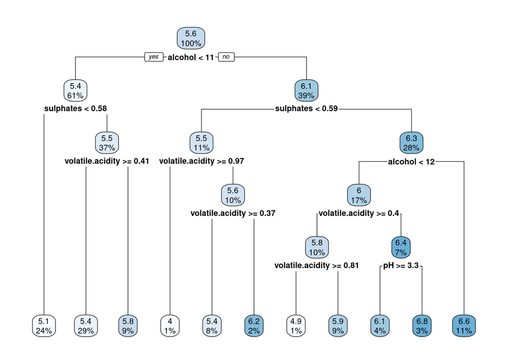

```r
rpart.plot(arbre_cart)
```

### 2.4 Erreur de généralisation et comparer les vraies valeurs aux prédictions

L’Erreur Quadratique Moyenne est la métrique de performance que nous utiliserons pour évaluer la qualité des modèles de régression. Elle mesure la moyenne des carrés des erreurs, c’est-à-dire la moyenne des carrés des différences entre les valeurs prédites et les valeurs réelles. Plus celle-ci est faible, plus le modèle est bien ajusté à nos données et donc plus précis.

```r
#Erreur de prédictions
predictions_cart <- predict(arbre_cart, test)
mse <- mean((predictions_cart - test$quality )^2)
print(paste("Erreur de généralisation (MSE) : ", mse))
```

```
## [1] "Erreur de généralisation (MSE) :  0.459916969885467"
```

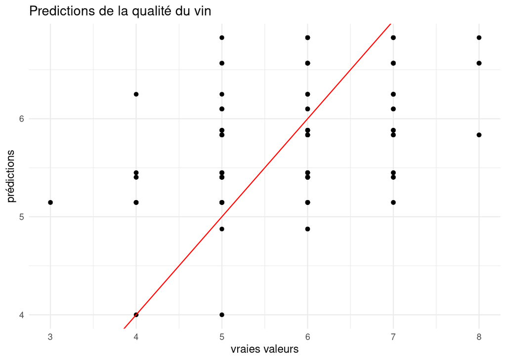

```r
data <- data.frame(TrueValues = test$quality, PredictedValues = predictions_cart)

ggplot(data, aes(x = TrueValues, y = PredictedValues)) +
  geom_point() +
  geom_abline(intercept = 0, slope = 1, color = "red") +
  theme_minimal() +
  labs(x = "vraies valeurs", y = "prédictions", title = "Predictions de la qualité du vin")
```

### 2.5 Robustesse

Les arbres CART, bien que puissants pour la modélisation et la visualisation, présentent une sensibilité notable à de petits changements dans les données. Cela peut se traduire par une grande variabilité dans la structure de l’arbre pour de légères modifications du jeu de données.

En observant les quatre arbres ci dessous, nous pouvons constater que chaque arbre diffère dans sa structure, ses nœuds de division et ses critères de division, malgré le fait qu’ils soient issus de jeux de données très similaires ou de sous-ensembles de données. Cette variabilité souligne le **manque de robustesse** des arbres CART.

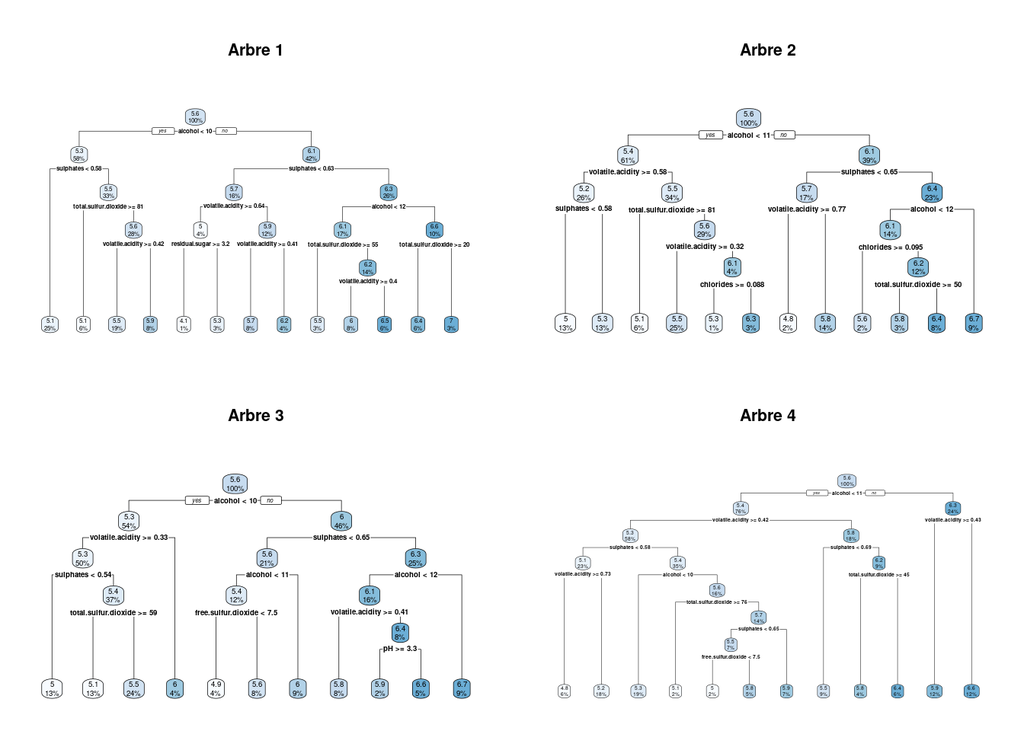

```r
num_trees <- 4  # Nombre d'arbres à générer

# Créez une liste pour stocker les arbres
arbres <- list()

# Générez et stockez les arbres dans la liste
for (i in 1:num_trees) {
  index <- createDataPartition(wine_quality$quality, p = 0.5, list = FALSE)
  training_sample <- wine_quality[index, ]
  arbres[[i]] <- rpart(quality ~ ., data = training_sample)
}

par(mfrow=c(2, 2))  # Crée une grille pour afficher plusieurs arbres

# Affichez chaque arbre dans la grille
for (i in 1:num_trees) {
  rpart.plot(arbres[[i]], main = paste("Arbre", i))
}
```

En pratique, pour obtenir des modèles plus robustes et moins sensibles aux variations, on utilise souvent les forêts aléatoires. Les forêts aléatoires, en combinant plusieurs arbres CART (où chaque arbre est formé à partir d’un sous-ensemble de données et d’un sous-ensemble de variables), permettent de “moyenner” les prédictions et d’atténuer les effets des instabilités individuelles des arbres.